# Assignment 2 Linear Model

Saad Siddiqui

17 November, 2023

#### Question 2

### Dataset 1

Observations: 1) The relationship between variables is not a straight line, and the spread of data increases as the expected value of Y changes. Additionally, a few unusual data points are present.

2. One potential solution could involve changing the way the dependent variable (Y) is represented before fitting the model.

### Dataset 2

Observations: 1) The relationship doesn’t follow a straight line, and the expected value of Y doesn’t consistently rise or fall with the predictor.

2. To address this, it might be helpful to try a different modeling approach, such as using a polynomial regression that includes an X^2 term.

### Dataset 3

Observations: 1) Using a simple linear regression seems suitable for this dataset, suggesting a linear relationship between variables.

2. The data shows a moderate skewness, which should be noted when reporting the findings.

### Dataset 4

Observations: 1) An outlier exists in this dataset, which could impact the model’s accuracy. Removing this outlier might help in achieving a better model fit.

2. After eliminating the outlier, re-fitting the model could provide more accurate insights from the data.

#### Question 3

a.b.

```r
x <- c(1:30)
e <- rnorm(n=30, mean=0, sd=4)
y <- 10 + 2*x + e
df <- data.frame(x,y,e)
df
```

```
##     x        y           e
## 1   1 11.90072 -0.09927920
## 2   2 17.94288  3.94288069
## 3   3 17.72190  1.72190097
## 4   4 18.91110  0.91110253
## 5   5 18.55892 -1.44108009
## 6   6 16.53467 -5.46533234
## 7   7 22.32232 -1.67768489
## 8   8 28.63767  2.63767462
## 9   9 40.50221 12.50221255
## 10 10 29.64300 -0.35699508
## 11 11 29.84094 -2.15906180
## 12 12 25.64632 -8.35367837
## 13 13 34.04180 -1.95820422
## 14 14 31.10697 -6.89302615
```

[output cut: 16 more lines]

```r
plot(x,y)
fit <- lm(y~x, data=df)
summary(fit)
```

```
##
## Call:
## lm(formula = y ~ x, data = df)
##
## Residuals:
##     Min      1Q  Median      3Q     Max
## -7.8049 -2.5584  0.3624  1.8242 12.8498
##
## Coefficients:
##             Estimate Std. Error t value Pr(>|t|)
## (Intercept) 10.25617    1.57148   6.526 4.49e-07 ***
## x            1.93292    0.08852  21.836  < 2e-16 ***
## ---
## Signif. codes:  0 '***' 0.001 '**' 0.01 '*' 0.05 '.' 0.1 ' ' 1
##
## Residual standard error: 4.197 on 28 degrees of freedom
## Multiple R-squared:  0.9445, Adjusted R-squared:  0.9426
## F-statistic: 476.8 on 1 and 28 DF,  p-value: < 2.2e-16
```

```r
abline(coef(fit)[1], coef(fit)[2], col=4, lty=2, lwd=2)




#Fit the new line
fit_new <- lm(x~y)
summary(fit_new)
```

```
##
## Call:
## lm(formula = x ~ y)
##
## Residuals:
##    Min     1Q Median     3Q    Max
## -6.640 -1.036 -0.056  1.630  3.620
##
## Coefficients:
##             Estimate Std. Error t value Pr(>|t|)
## (Intercept) -4.15203    0.97896  -4.241 0.000219 ***
## y            0.48866    0.02238  21.836  < 2e-16 ***
## ---
## Signif. codes:  0 '***' 0.001 '**' 0.01 '*' 0.05 '.' 0.1 ' ' 1
##
## Residual standard error: 2.11 on 28 degrees of freedom
## Multiple R-squared:  0.9445, Adjusted R-squared:  0.9426
## F-statistic: 476.8 on 1 and 28 DF,  p-value: < 2.2e-16
```

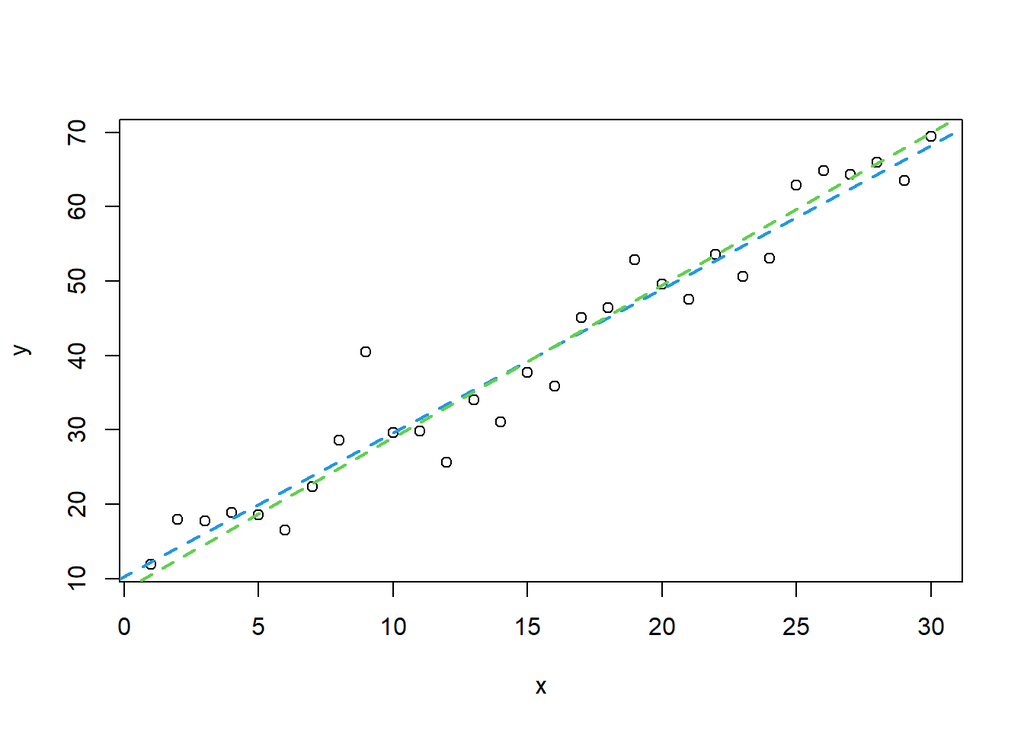

[output not shown]

```r
c <- coef(fit_new)[1]
d <- coef(fit_new)[2]
a <- -c/d
b <- 1/d
abline(a,b, col= 3, lty=2, lwd=2)
```

#### Question 4

```r
library(tidyverse)
pollen <- read_table("pollen.txt")
pollen |> head()
```

```
## # A tibble: 6 × 3
##   removed duration  code
##     <dbl>    <dbl> <dbl>
## 1  0.0700        2     1
## 2  0.100         5     1
## 3  0.110         7     1
## 4  0.120        11     1
## 5  0.150        12     1
## 6  0.190        11     1
```

```r
pollen <- pollen |> filter(code==1)
pollen_c <- pollen |>
filter(duration < 31)

fit1 <- lm(removed~ duration , data= pollen)
summary(fit1)
```

```
##
## Call:
## lm(formula = removed ~ duration, data = pollen)
##
## Residuals:
##      Min       1Q   Median       3Q      Max
## -0.26437 -0.11327  0.04184  0.10700  0.28321
##
## Coefficients:
##             Estimate Std. Error t value Pr(>|t|)
## (Intercept) 0.295204   0.053640   5.503 4.17e-06 ***
## duration    0.008106   0.002831   2.863  0.00724 **
## ---
## Signif. codes:  0 '***' 0.001 '**' 0.01 '*' 0.05 '.' 0.1 ' ' 1
##
## Residual standard error: 0.1653 on 33 degrees of freedom
## Multiple R-squared:  0.1989, Adjusted R-squared:  0.1747
## F-statistic: 8.196 on 1 and 33 DF,  p-value: 0.00724
```

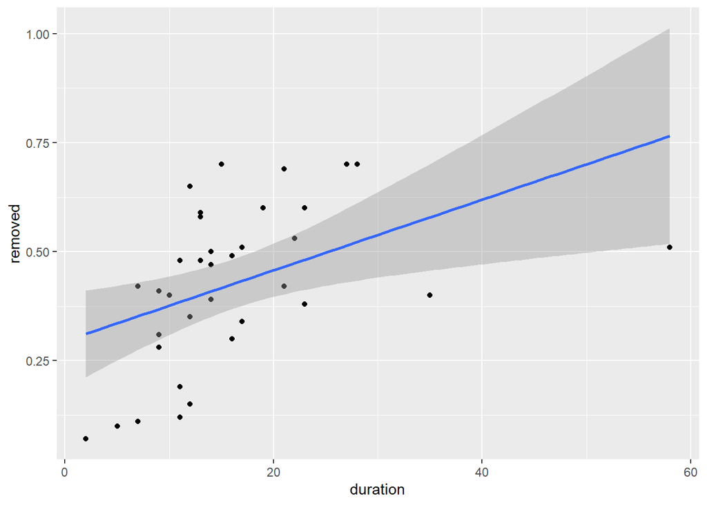

```r
ggplot(data=pollen,
       aes(x=duration, y=removed))+
  geom_point()+
  geom_smooth(method="lm")
```

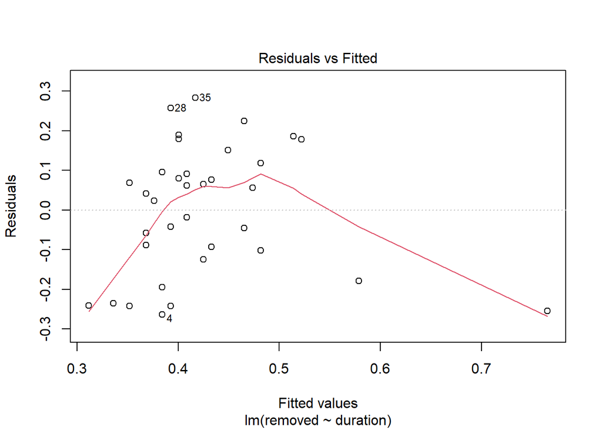

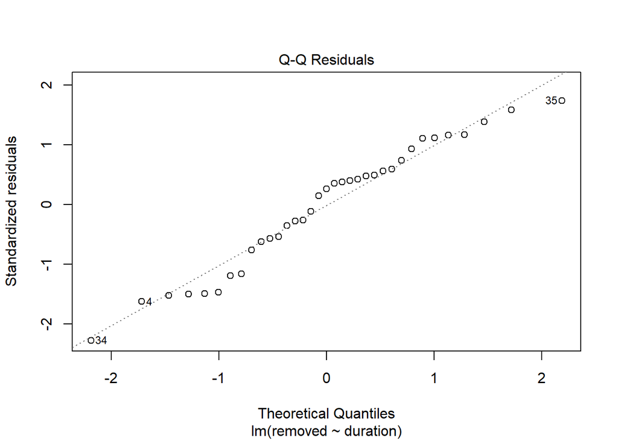

```r
plot(fit1,which = c(1,2))
```